# Report of exercise 4

## Preparation of the data for LDA

Next, the data needs to be scaled for further analysis (because in linear discriminant analysis the variables need to have the same variance). After scaling, data has transformed as matrix, so let’s change it to data frame again.

```r
boston_scaled <- scale(Boston)
summary(boston_scaled)
```

```
##       crim                 zn               indus              chas
##  Min.   :-0.419367   Min.   :-0.48724   Min.   :-1.5563   Min.   :-0.2723
##  1st Qu.:-0.410563   1st Qu.:-0.48724   1st Qu.:-0.8668   1st Qu.:-0.2723
##  Median :-0.390280   Median :-0.48724   Median :-0.2109   Median :-0.2723
##  Mean   : 0.000000   Mean   : 0.00000   Mean   : 0.0000   Mean   : 0.0000
##  3rd Qu.: 0.007389   3rd Qu.: 0.04872   3rd Qu.: 1.0150   3rd Qu.:-0.2723
##  Max.   : 9.924110   Max.   : 3.80047   Max.   : 2.4202   Max.   : 3.6648
##       nox                rm               age               dis
##  Min.   :-1.4644   Min.   :-3.8764   Min.   :-2.3331   Min.   :-1.2658
##  1st Qu.:-0.9121   1st Qu.:-0.5681   1st Qu.:-0.8366   1st Qu.:-0.8049
##  Median :-0.1441   Median :-0.1084   Median : 0.3171   Median :-0.2790
##  Mean   : 0.0000   Mean   : 0.0000   Mean   : 0.0000   Mean   : 0.0000
##  3rd Qu.: 0.5981   3rd Qu.: 0.4823   3rd Qu.: 0.9059   3rd Qu.: 0.6617
##  Max.   : 2.7296   Max.   : 3.5515   Max.   : 1.1164   Max.   : 3.9566
##       rad               tax             ptratio            black
##  Min.   :-0.9819   Min.   :-1.3127   Min.   :-2.7047   Min.   :-3.9033
##  1st Qu.:-0.6373   1st Qu.:-0.7668   1st Qu.:-0.4876   1st Qu.: 0.2049
##  Median :-0.5225   Median :-0.4642   Median : 0.2746   Median : 0.3808
##  Mean   : 0.0000   Mean   : 0.0000   Mean   : 0.0000   Mean   : 0.0000
##  3rd Qu.: 1.6596   3rd Qu.: 1.5294   3rd Qu.: 0.8058   3rd Qu.: 0.4332
##  Max.   : 1.6596   Max.   : 1.7964   Max.   : 1.6372   Max.   : 0.4406
##      lstat              medv
##  Min.   :-1.5296   Min.   :-1.9063
##  1st Qu.:-0.7986   1st Qu.:-0.5989
##  Median :-0.1811   Median :-0.1449
##  Mean   : 0.0000   Mean   : 0.0000
##  3rd Qu.: 0.6024   3rd Qu.: 0.2683
##  Max.   : 3.5453   Max.   : 2.9865
```

```r
class(boston_scaled)
```

```
## [1] "matrix" "array"
```

```r
boston_scaled <- as.data.frame(boston_scaled)

par(fmrow = c(7,2))
```

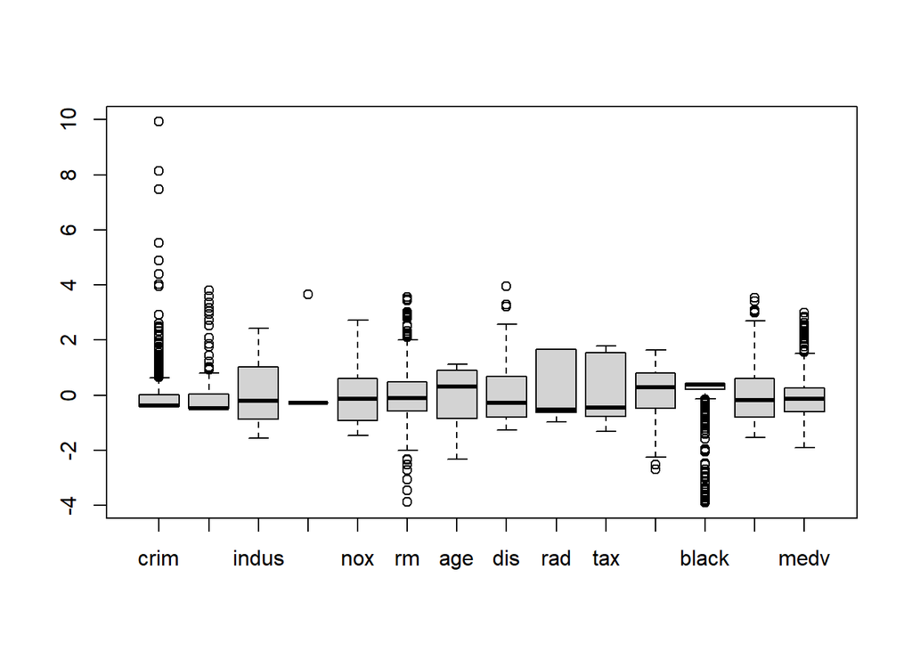

```r
boxplot(boston_scaled)
```

Before scaling, there was e.g. one variable (chas) with variation [0,1] and another (tax) with variation [187,711]. After scaling, the mean of all the variables is the same (0), and all the values of all the variables are between about -4 and 10.

Our aim in the next analysis is to predict crime rates of the suburb with other variables. In order to do this with linear discriminant analysis, variable ‘crim’ must be categorized. After categorization the old crim-variable will be replaced with the categorized one.

```r
summary(boston_scaled$crim)
```

```
##      Min.   1st Qu.    Median      Mean   3rd Qu.      Max.
## -0.419367 -0.410563 -0.390280  0.000000  0.007389  9.924110
```

```r
bins <- quantile(boston_scaled$crim)
name_bins <- c("low","med_low","med_high","high")
crime <- cut(boston_scaled$crim, breaks = bins, include.lowest = TRUE,label=name_bins)
table(crime)
```

```
## crime
##      low  med_low med_high     high
##      127      126      126      127
```

```r
boston_scaled <- dplyr::select(boston_scaled, -crim)
boston_scaled <- data.frame(boston_scaled, crime)
```

Because we used the quantiles as cut-points, every category has about as many observations. So the categorization succeeded,

```r
n <- nrow(boston_scaled)

ind <- sample(n,  size = n * 0.8)

train <- boston_scaled[ind,]

test <- boston_scaled[-ind,]
```

## The LDA model

Now, we are ready to fit a linear discriminant analysis to the train set. The goal is to see, which variables separate the crimerate-classes the best.

```r
lda.fit <- lda(crime~., data = train)


lda.fit
```

```
## Call:
## lda(crime ~ ., data = train)
##
## Prior probabilities of groups:
##       low   med_low  med_high      high
## 0.2500000 0.2450495 0.2549505 0.2500000
##
## Group means:
##                  zn      indus          chas        nox         rm        age
## low       0.9688843 -0.9243739 -0.0774231154 -0.8788203  0.3839383 -0.9235078
## med_low  -0.1227845 -0.3103487 -0.0337169322 -0.5628463 -0.1784929 -0.3223179
## med_high -0.3856672  0.2264479  0.2628107702  0.3901343  0.1471428  0.4354744
## high     -0.4872402  1.0171306  0.0005392655  1.0904123 -0.4112358  0.8557176
##                 dis        rad        tax     ptratio       black       lstat
## low       0.8832729 -0.6930488 -0.7306292 -0.46606205  0.38371182 -0.75824125
## med_low   0.3598703 -0.5456857 -0.4749413 -0.09003808  0.31057550 -0.09013636
## med_high -0.3863263 -0.4098677 -0.2936996 -0.29517082  0.05305276 -0.04163738
## high     -0.8744333  1.6379981  1.5139626  0.78062517 -0.87603826  0.92885019
##                 medv
## low       0.48851641
## med_low  -0.04178723
## med_high  0.17800131
## high     -0.74023886
##
## Coefficients of linear discriminants:
##                 LD1         LD2         LD3
## zn       0.10961674  0.61947230 -1.00443493
## indus    0.07227794 -0.37738690  0.22586585
## chas    -0.09006561  0.00894953  0.04121049
## nox      0.36244869 -0.75218828 -1.25212508
## rm      -0.12070135 -0.12762416 -0.17642366
## age      0.24051145 -0.48428180 -0.14120668
## dis     -0.07417866 -0.32218009  0.23475072
## rad      3.20699862  0.86789492 -0.03984783
## tax     -0.05454077  0.15643226  0.49308723
## ptratio  0.07838184 -0.02503488 -0.28783989
## black   -0.11332449  0.02687911  0.12106912
## lstat    0.21056576 -0.10872608  0.50228438
## medv     0.18711553 -0.40532060 -0.11130987
##
## Proportion of trace:
##    LD1    LD2    LD3
## 0.9438 0.0421 0.0141
```

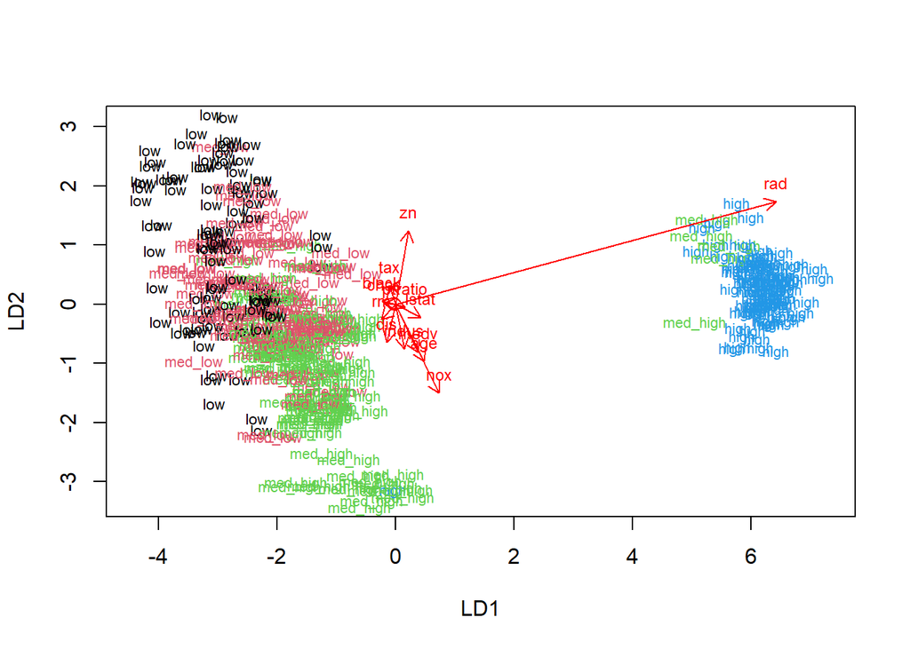

```r
lda.arrows <- function(x, myscale = 1, arrow_heads = 0.1, color = "red", tex = 0.75, choices = c(1,2)){
  heads <- coef(x)
  arrows(x0 = 0, y0 = 0,
         x1 = myscale * heads[,choices[1]],
         y1 = myscale * heads[,choices[2]], col=color, length = arrow_heads)
  text(myscale * heads[,choices], labels = row.names(heads),
       cex = tex, col=color, pos=3)
}

classes <- as.numeric(train$crime)

plot(lda.fit, dimen = 2, col=classes, pch=classes)
lda.arrows(lda.fit, myscale = 2
)
```

LD1 indicates the amount of variance between the groups explained by LD1 (about 95 %). If I understand right from the picture, in this model rad (an indication of accessibility) and zn (related to zoning) and nox (nitrogen oxides concentration) are the variables influencing the grouping the most.